# salmon outmigrant phenology

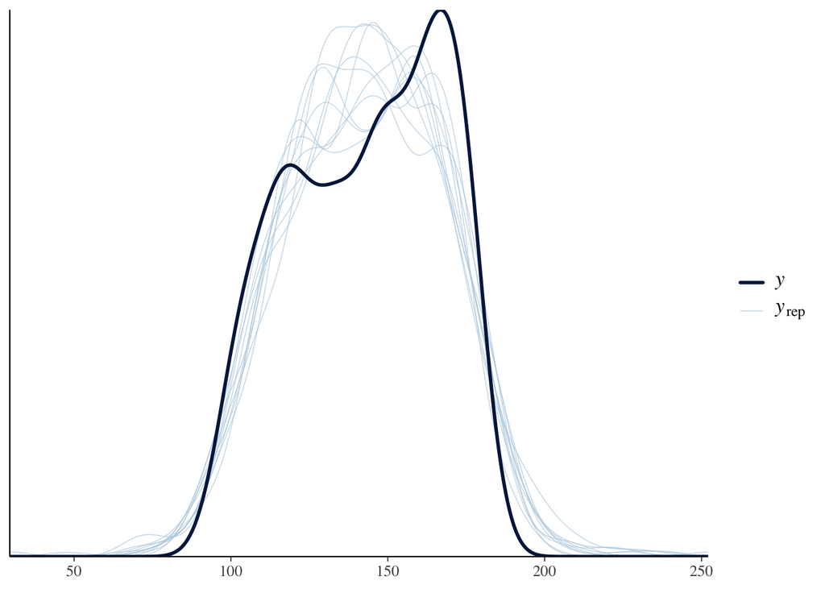

```r
# early, mid and late allows us to see there's a real effect of the ff timing
# albeit primarily on those first, early migrants

# define some priors based earlier model output
my_priors <- c(
  prior(normal(150, 50), class = Intercept),
  prior(normal(0, 1), class = b, coef = ff_wyd),
  prior(normal(0, 1), class = b, coef = "ff_wyd:percentileday_50"),
  prior(normal(0, 1), class = b, coef = "ff_wyd:percentileday_90"),
  prior(normal(0, 2), class = b, coef = wy_meanCentered),
  prior(normal(0, 30), class = b), # now only hits percentile & region contrasts
  prior(normal(0, 20), class = sd),
  prior(exponential(1), class = sigma),
  prior(gamma(2, 0.1), class = nu)
)

bmod5 <- brm(
  data = ff_data,
  wyd ~ 1 + ff_wyd * percentile + region + wy_meanCentered + (1 | wy),
  family = student,
  prior = my_priors,
  iter = 2000, warmup = 1000, chains = 4, cores = 4,
  seed = 42,
  file = here("salmon/results/bmod5"),
  file_refit = "on_change"
)

pp_check(bmod5) # looks GREAT
```

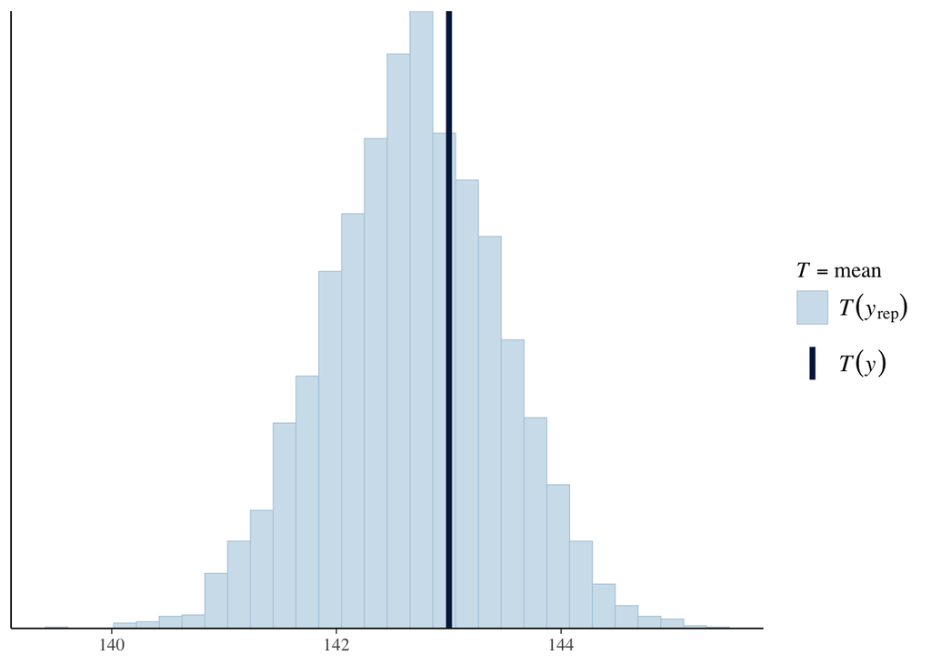

```r
pp_check(bmod5, type = "stat", stat = "mean")
```

```r
(bmod5_sum <- summary(bmod5)) # what's going on w S Delta? SJR fish?!
```

```
 Family: student
  Links: mu = identity
Formula: wyd ~ 1 + ff_wyd * percentile + region + wy_meanCentered + (1 | wy)
   Data: ff_data (Number of observations: 480)
  Draws: 4 chains, each with iter = 2000; warmup = 1000; thin = 1;
         total post-warmup draws = 4000

Multilevel Hyperparameters:
~wy (Number of levels: 45)
              Estimate Est.Error l-95% CI u-95% CI Rhat Bulk_ESS Tail_ESS
sd(Intercept)     6.88      0.95     5.25     8.91 1.00     1476     1810

Regression Coefficients:
                           Estimate Est.Error l-95% CI u-95% CI Rhat Bulk_ESS
Intercept                    101.41      4.04    93.53   109.45 1.00     1731
ff_wyd                         0.21      0.04     0.13     0.29 1.00     1843
percentileday_50              38.08      3.53    31.23    44.91 1.00     3163
percentileday_90              69.40      3.57    62.26    76.11 1.00     2961
regionLowerSacramentoRiver    -8.16      1.24   -10.57    -5.67 1.00     5759
regionNorthDelta              -2.46      1.19    -4.78    -0.15 1.00     5215
regionSouthDelta               1.23      1.70    -2.10     4.54 1.00     6085
wy_meanCentered               -0.30      0.09    -0.47    -0.12 1.00     1639
ff_wyd:percentileday_50       -0.15      0.04    -0.23    -0.08 1.00     3137
ff_wyd:percentileday_90       -0.23      0.04    -0.30    -0.15 1.00     3053
                           Tail_ESS
Intercept                      2563
ff_wyd                         2430
percentileday_50               3004
percentileday_90               3020
regionLowerSacramentoRiver     3193
regionNorthDelta               3422
regionSouthDelta               3515
wy_meanCentered                2332
ff_wyd:percentileday_50        3054
ff_wyd:percentileday_90        3110

Further Distributional Parameters:
      Estimate Est.Error l-95% CI u-95% CI Rhat Bulk_ESS Tail_ESS
sigma     8.56      0.57     7.47     9.72 1.00     3776     3430
nu        3.95      0.88     2.62     6.10 1.00     4050     3514

Draws were sampled using sampling(NUTS). For each parameter, Bulk_ESS
and Tail_ESS are effective sample size measures, and Rhat is the potential
scale reduction factor on split chains (at convergence, Rhat = 1).
```

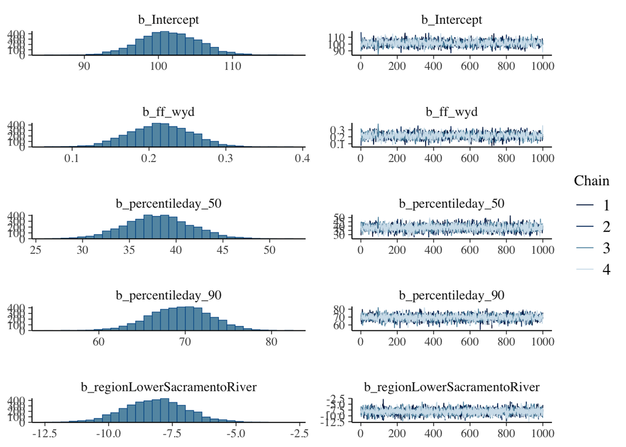

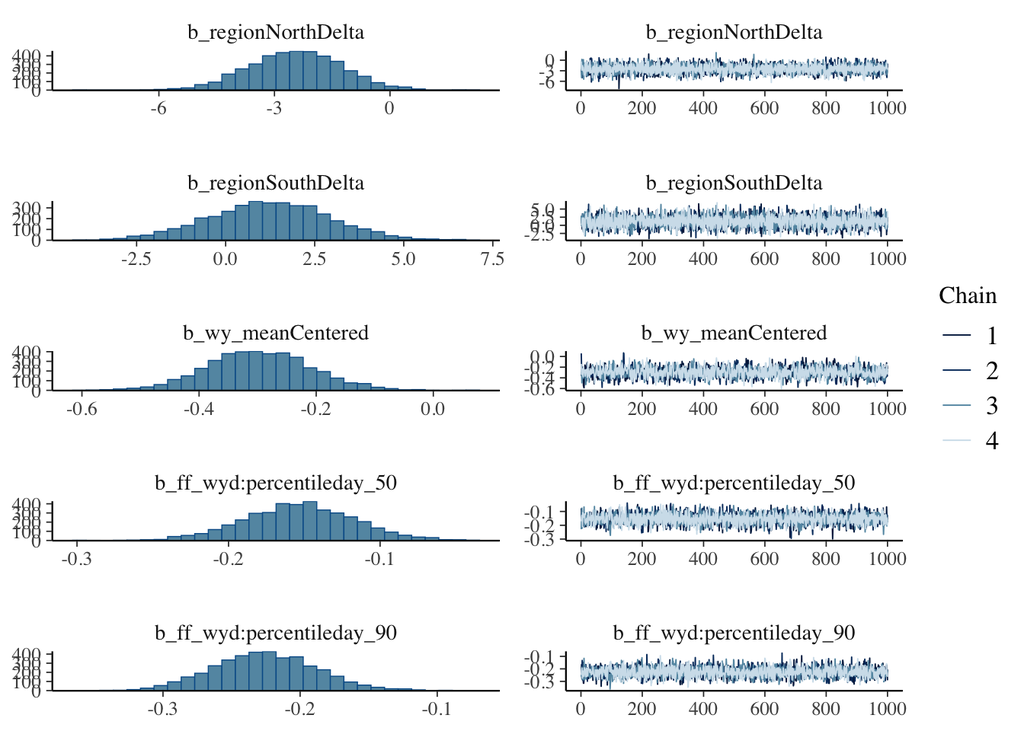

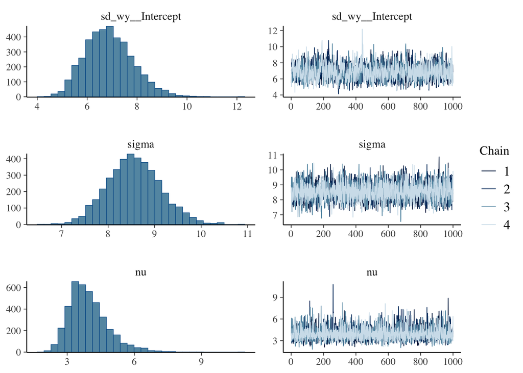

```r
plot(bmod5) # looks good
```

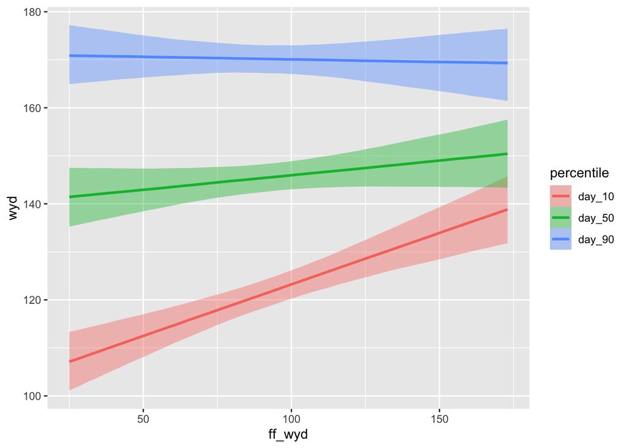

```r
conditional_effects(bmod5, "ff_wyd:percentile")
```

The diagnostics look clean again — all `Rhat` = 1.00, ESS well above 1000, and `nu` well below 10. The results look really good, but I think we should add water year type to the model to see if overall water year conditions affect migration timing. This could, for example, affect the tail end of the migration (`day_90`) while having little or no effect on the first 10%.

```r
# we're going to have to revise the priors though:
get_prior(
  wyd ~ 1 + ff_wyd * percentile + region + wy_meanCentered + mo(wyt) + (1 | wy),
  data = ff_data,
  family = student
) # this is mostly to ensure that I'm using the right terms
```

```
                     prior     class                       coef group resp dpar
                    (flat)         b
                    (flat)         b                     ff_wyd
                    (flat)         b    ff_wyd:percentileday_50
                    (flat)         b    ff_wyd:percentileday_90
                    (flat)         b                      mowyt
                    (flat)         b           percentileday_50
                    (flat)         b           percentileday_90
                    (flat)         b regionLowerSacramentoRiver
                    (flat)         b           regionNorthDelta
                    (flat)         b           regionSouthDelta
                    (flat)         b            wy_meanCentered
 student_t(3, 146.5, 28.9) Intercept
             gamma(2, 0.1)        nu
     student_t(3, 0, 28.9)        sd
     student_t(3, 0, 28.9)        sd                               wy
     student_t(3, 0, 28.9)        sd                  Intercept    wy
     student_t(3, 0, 28.9)     sigma
              dirichlet(1)      simo                     mowyt1
 nlpar lb ub tag       source
                      default
                 (vectorized)
                 (vectorized)
                 (vectorized)
                 (vectorized)
                 (vectorized)
                 (vectorized)
                 (vectorized)
                 (vectorized)
                 (vectorized)
                 (vectorized)
                      default
        1             default
        0             default
        0        (vectorized)
        0        (vectorized)
        0             default
                      default
```

```
Using 10 posterior draws for ppc type 'dens_overlay' by default.
```

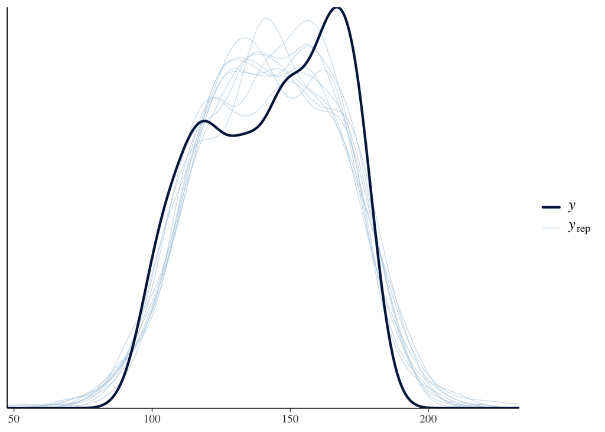

```r
my_priors_bmod6 <- c(
  prior(normal(150, 50), class = Intercept),
  prior(normal(0, 1), class = b, coef = ff_wyd),
  prior(normal(0, 1), class = b, coef = "ff_wyd:percentileday_50"),
  prior(normal(0, 1), class = b, coef = "ff_wyd:percentileday_90"),
  prior(normal(0, 2), class = b, coef = wy_meanCentered),
  prior(normal(0, 30), class = b, coef = mowyt),
  prior(normal(0, 30), class = b), # percentile & region contrasts
  prior(normal(0, 20), class = sd),
  prior(exponential(1), class = sigma),
  prior(gamma(2, 0.1), class = nu),
  prior(dirichlet(1), class = simo, coef = mowyt1)
)

bmod6 <- brm(
  data = ff_data,
  # note addition of the monotonic wyt
  wyd ~ 1 + ff_wyd * percentile + region + wy_meanCentered + mo(wyt) + (1 | wy),
  # sample_prior = "only", # run pp_check(bmod6); if ok run without
  family = student,
  prior = my_priors_bmod6,
  iter = 2000, warmup = 1000, chains = 4, cores = 4,
  seed = 42,
  file = here("salmon/results/bmod6"),
  file_refit = "on_change"
)
pp_check(bmod6)
```

```
Using all posterior draws for ppc type 'stat' by default.
```

```
Note: in most cases the default test statistic 'mean' is too weak to detect anything of interest.
```

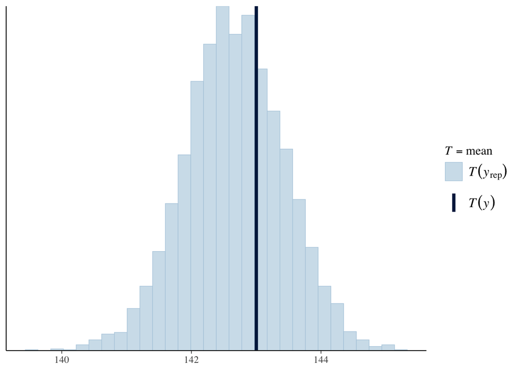

```r
pp_check(bmod6, type = "stat", stat = "mean")
```

```r
(bmod6_sum <- summary(bmod6)) # what's going on w S Delta? SJR fish?!
```

```
 Family: student
  Links: mu = identity
Formula: wyd ~ 1 + ff_wyd * percentile + region + wy_meanCentered + mo(wyt) + (1 | wy)
   Data: ff_data (Number of observations: 480)
  Draws: 4 chains, each with iter = 2000; warmup = 1000; thin = 1;
         total post-warmup draws = 4000

Multilevel Hyperparameters:
~wy (Number of levels: 45)
              Estimate Est.Error l-95% CI u-95% CI Rhat Bulk_ESS Tail_ESS
sd(Intercept)     7.02      0.98     5.33     9.22 1.00     1465     2498

Regression Coefficients:
                           Estimate Est.Error l-95% CI u-95% CI Rhat Bulk_ESS
Intercept                    101.83      5.12    91.96   112.11 1.00     1314
ff_wyd                         0.21      0.04     0.13     0.30 1.00     1307
percentileday_50              37.99      3.48    31.23    44.74 1.00     2451
percentileday_90              69.37      3.57    62.20    76.25 1.00     2318
regionLowerSacramentoRiver    -8.19      1.25   -10.68    -5.74 1.00     5225
regionNorthDelta              -2.49      1.18    -4.80    -0.14 1.00     5563
regionSouthDelta               1.20      1.69    -2.16     4.58 1.00     6178
wy_meanCentered               -0.29      0.09    -0.48    -0.11 1.00     1371
ff_wyd:percentileday_50       -0.15      0.04    -0.22    -0.08 1.00     2529
ff_wyd:percentileday_90       -0.23      0.04    -0.30    -0.15 1.00     2319
mowyt                         -0.09      0.82    -1.63     1.55 1.00     1231
                           Tail_ESS
Intercept                      2107
ff_wyd                         2108
percentileday_50               2891
percentileday_90               2637
regionLowerSacramentoRiver     3350
regionNorthDelta               3573
regionSouthDelta               3287
wy_meanCentered                2100
ff_wyd:percentileday_50        2354
ff_wyd:percentileday_90        2769
mowyt                          1678

Monotonic Simplex Parameters:
          Estimate Est.Error l-95% CI u-95% CI Rhat Bulk_ESS Tail_ESS
mowyt1[1]     0.26      0.20     0.01     0.73 1.00     4363     2521
mowyt1[2]     0.24      0.19     0.01     0.71 1.00     5318     2798
mowyt1[3]     0.24      0.19     0.01     0.71 1.00     5146     2836
mowyt1[4]     0.25      0.19     0.01     0.72 1.00     5334     3233

Further Distributional Parameters:
      Estimate Est.Error l-95% CI u-95% CI Rhat Bulk_ESS Tail_ESS
sigma     8.56      0.58     7.46     9.74 1.00     2876     2977
nu        3.96      0.92     2.67     6.12 1.00     3311     3200

Draws were sampled using sampling(NUTS). For each parameter, Bulk_ESS
and Tail_ESS are effective sample size measures, and Rhat is the potential
scale reduction factor on split chains (at convergence, Rhat = 1).
```

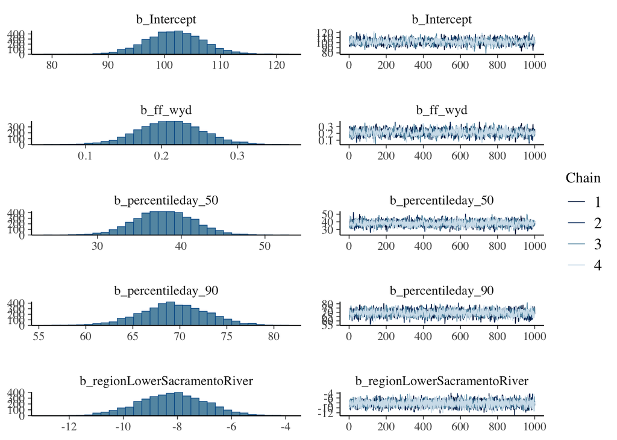

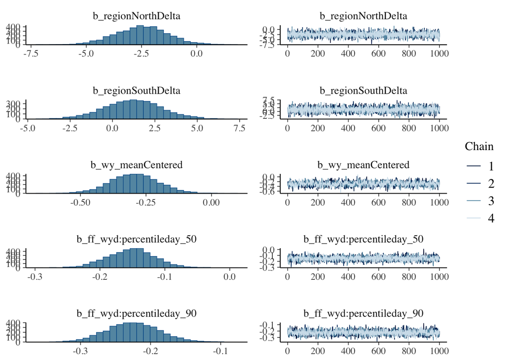

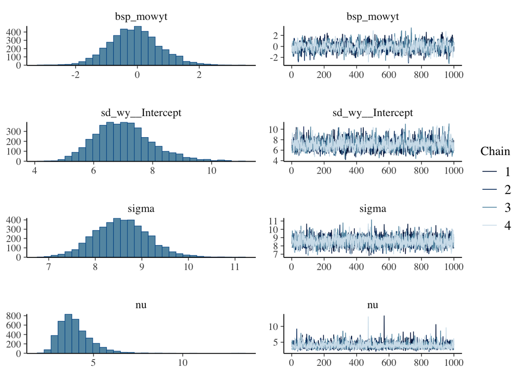

```r
plot(bmod6) # looks good
```

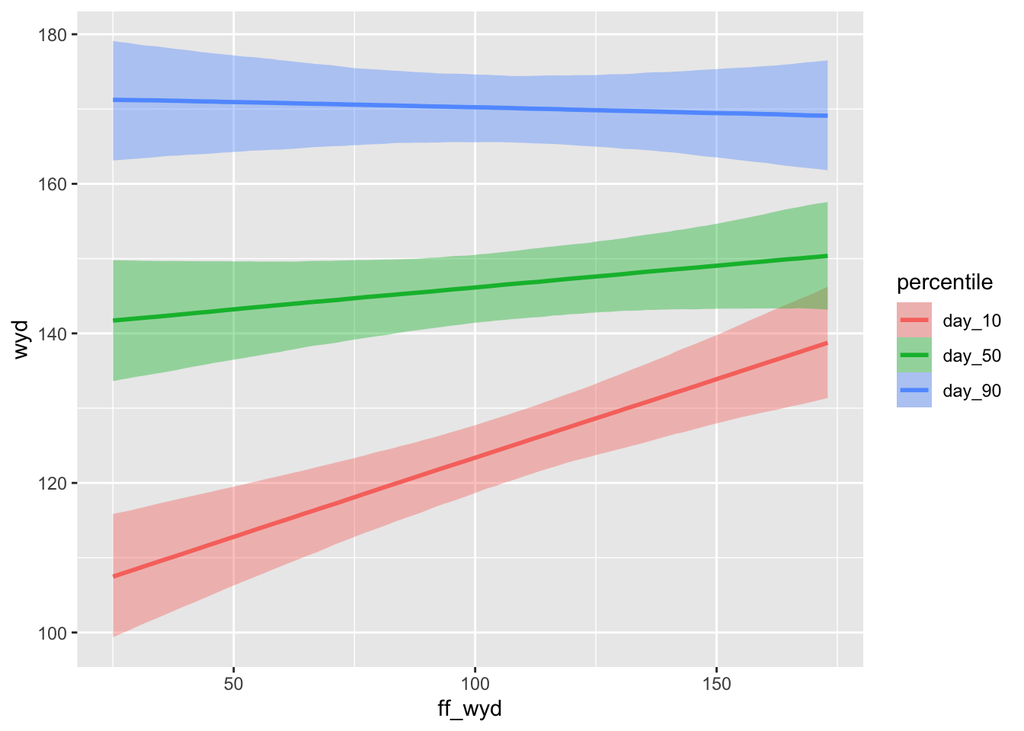

```r
conditional_effects(bmod6, "ff_wyd:percentile")
```

```r
bmod5 <- add_criterion(bmod5, "loo")
bmod6 <- add_criterion(bmod6, "loo")
loo_compare(bmod5, bmod6)
```

```
      elpd_diff se_diff
bmod6  0.0       0.0
bmod5 -0.3       0.2
```

The model including water year type (`bmod6`) showed negligible improvement in predictive accuracy over the simpler model, `bmod5`, (Δelpd = –0.3 ± 0.2), and the water year type coefficient was not credibly different from zero, so we should go with the more parsimonious `bmod5`.